# **IPL Dashboard**

## Some Cleaning, Transformation & Analysis

Since all the values are NaN, filling all the NaN values with 0.

Number of unique team present in dataset - matches

```
array(['Sunrisers Hyderabad', 'Mumbai Indians', 'Gujarat Lions',
       'Rising Pune Supergiant', 'Royal Challengers Bangalore',
       'Kolkata Knight Riders', 'Delhi Daredevils', 'Kings XI Punjab',
       'Chennai Super Kings', 'Rajasthan Royals', 'Deccan Chargers',
       'Kochi Tuskers Kerala', 'Pune Warriors', 'Rising Pune Supergiants'],
      dtype=object)
```

Changing team name with it's short names.

```
array(['MI', 'KKR', 'RCB', 'DC', 'CSK', 'RR', 'DD', 'GL', 'KXIP', 'SRH',
       'RPS', 'KTK', 'PW'], dtype=object)
```

Number of unique team present in dataset - delivery

```
array(['Sunrisers Hyderabad', 'Royal Challengers Bangalore',
       'Mumbai Indians', 'Rising Pune Supergiant', 'Gujarat Lions',
       'Kolkata Knight Riders', 'Kings XI Punjab', 'Delhi Daredevils',
       'Chennai Super Kings', 'Rajasthan Royals', 'Deccan Chargers',
       'Kochi Tuskers Kerala', 'Pune Warriors', 'Rising Pune Supergiants'],
      dtype=object)
```

Changing team name with it's short names.

```
array(['MI', 'CSK', 'KKR', 'DC', 'RCB', 'RR', 'GL', 'DD', 'KXIP', 'SRH',
       'RPS', 'KTK', 'PW'], dtype=object)
```

Matches data set after cleaning

|  | id | season | city | date | team1 | team2 | toss_winner | toss_decision | result | dl_applied | winner | win_by_runs | win_by_wickets | player_of_match | venue | umpire1 | umpire2 |
| --- | --- | --- | --- | --- | --- | --- | --- | --- | --- | --- | --- | --- | --- | --- | --- | --- | --- |
| 0 | 1 | 2017 | Hyderabad | 2017-04-05 | MI | CSK | CSK | field | normal | 0 | MI | 35 | 0 | Yuvraj Singh | Rajiv Gandhi International Stadium, Uppal | AY Dandekar | NJ Llong |
| 1 | 2 | 2017 | Pune | 2017-04-06 | KKR | DC | DC | field | normal | 0 | DC | 0 | 7 | SPD Smith | Maharashtra Cricket Association Stadium | A Nand Kishore | S Ravi |

Delivery data set after cleaning

|  | match_id | inning | batting_team | bowling_team | over | ball | batsman | non_striker | bowler | is_super_over | ... | bye_runs | legbye_runs | noball_runs | penalty_runs | batsman_runs | extra_runs | total_runs | player_dismissed | dismissal_kind | fielder |
| --- | --- | --- | --- | --- | --- | --- | --- | --- | --- | --- | --- | --- | --- | --- | --- | --- | --- | --- | --- | --- | --- |
| 0 | 1 | 1 | MI | CSK | 1 | 1 | DA Warner | S Dhawan | TS Mills | 0 | ... | 0 | 0 | 0 | 0 | 0 | 0 | 0 | 0 | 0 | 0 |
| 1 | 1 | 1 | MI | CSK | 1 | 2 | DA Warner | S Dhawan | TS Mills | 0 | ... | 0 | 0 | 0 | 0 | 0 | 0 | 0 | 0 | 0 | 0 |

2 rows × 21 columns

**Some Basic Analysis**

```
Total Matches Played: 636

Venues Played At: ['Hyderabad' 'Pune' 'Rajkot' 'Indore' 'Bangalore' 'Mumbai' 'Kolkata'
 'Delhi' 'Chandigarh' 'Kanpur' 'Jaipur' 'Chennai' 'Cape Town'
 'Port Elizabeth' 'Durban' 'Centurion' 'East London' 'Johannesburg'
 'Kimberley' 'Bloemfontein' 'Ahmedabad' 'Cuttack' 'Nagpur' 'Dharamsala'
 'Kochi' 'Visakhapatnam' 'Raipur' 'Ranchi' 'Abu Dhabi' 'Sharjah' nan]

Teams : ['MI' 'KKR' 'RCB' 'DC' 'CSK' 'RR' 'DD' 'GL' 'KXIP' 'SRH' 'RPS' 'KTK' 'PW']
```

```
Total venues played at: 30

Total umpires  44
```

```
CH Gayle  : has most man of the match awards

KKR : has the highest number of match wins
```

Data of max number in column 'wins_by_runs' and output only shows coloumn - season, team1, team2, winner & wins_by runs

|  | season | team1 | team2 | winner | win_by_runs |
| --- | --- | --- | --- | --- | --- |
| 43 | 2017 | KKR | DD | KKR | 146 |

**KKR defeated DD with the highest run difference**

Data of max number in column 'wins_by_wickets' and output only shows coloumn - season, team1, team2, winner & wins_by_wickets.

|  | season | team1 | team2 | winner | win_by_wickets |
| --- | --- | --- | --- | --- | --- |
| 2 | 2017 | RCB | RR | RR | 10 |

## Toss Decisions, total maches vs wins, is toss winner also match winner?

```
Toss Decisions in %
 field    57.075472
bat      42.924528
Name: toss_decision, dtype: float64
```

**Toss Decisions across Seasons**

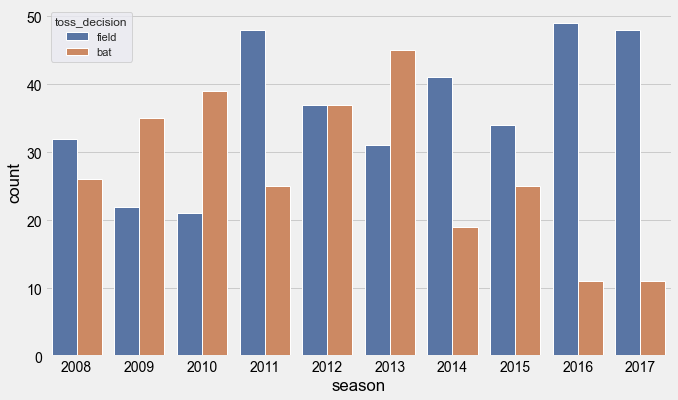

**Maximum Toss Winners**

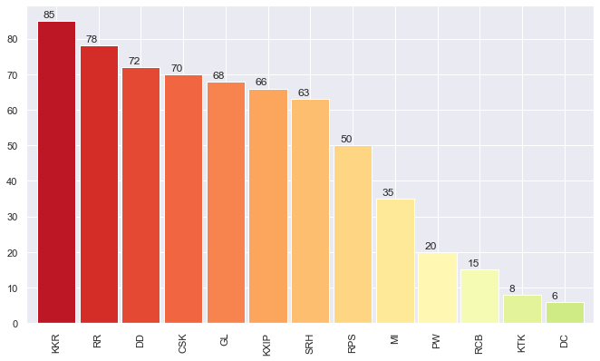

**Total Matches vs Wins for Teams (INTERACTIVE)**

[interactive chart not shown]

**Is Toss Winner Also the Match Winner?**

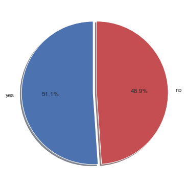

Thus the toss winner is not necessarily the match winner. The match winning probablity for toss winnong team is about 50%-50%

## Analysis based on seasons with matches played, avg runs, 6's, 4's, runs per over by teams & Favorite ground

**Matches played across each season**

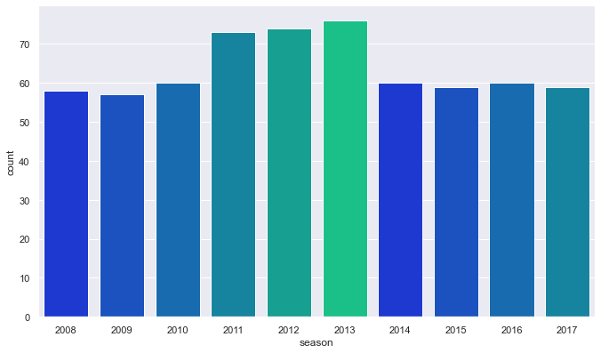

**Runs Across the Seasons**

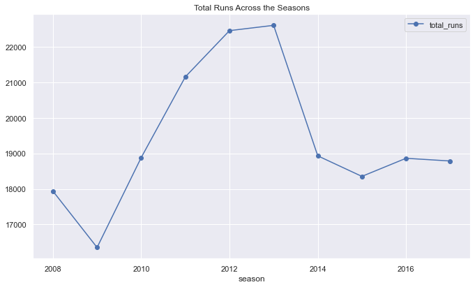

There was a decline in total runs from 2008 to 2009.But there after there was a substantial increase in runs in every season until 2013, but from next season there was a slump in the total runs. But the number of matches are not equal in all seasons. We should check the average runs per match in each season

**Average runs per match in each Season**

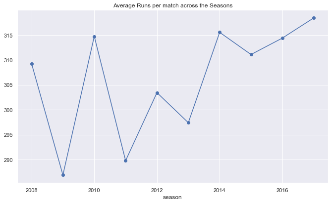

**Sixes and Fours Across the Season**

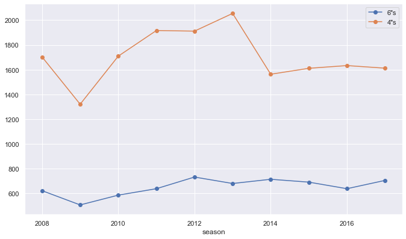

**Runs Per Over By Teams Across Seasons**

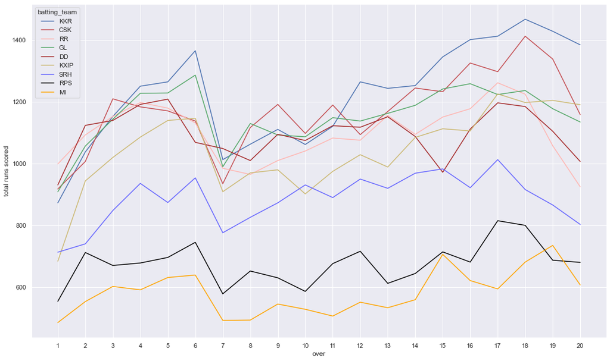

**Favorite grounds**

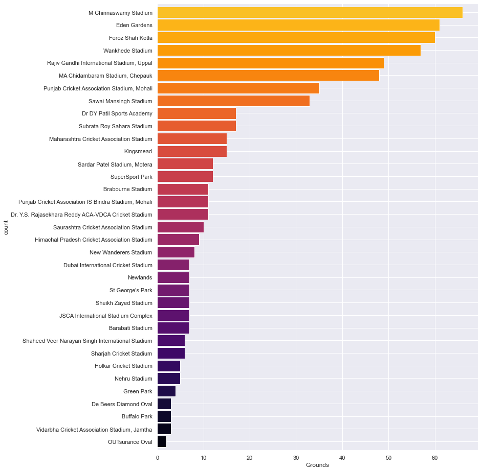

## Maximum Man Of Matches

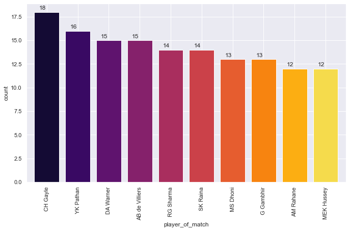

## Winners by Year

```
Winners By Years
[2008 'SRH']
[2009 'RPS']
[2010 'KXIP']
[2011 'KXIP']
[2012 'RR']
[2013 'KKR']
[2014 'RR']
[2015 'KKR']
[2016 'MI']
```

### Super Over!

```
 Total Matches with Super Overs: 7
```

```
Teams who haven"t ever played a super over are: ['RPS', 'KTK', 'PW', 'DC']
```

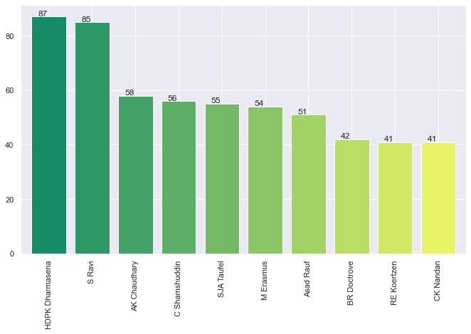

## Team1 vs Team2

Here we will check the matches played between 2 teams and which had won more matches each year

### MI vs KKR

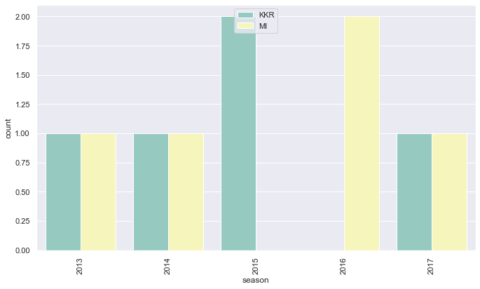

One thing to notice is that MI and KKR have never played against each other in any qualifiers or finals as both of them have played only 2 matches every year, those being the group stage matches.

### MI vs CSK

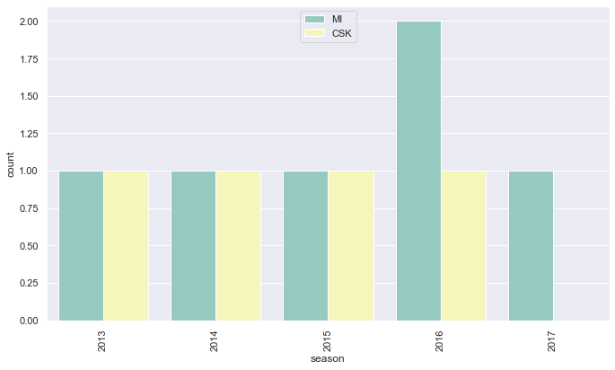

Here se can see that MI and CSK have played against each other in more than 2 matches in some seasons i.e they have played qualifiers too.

## Matches Won By A Team Against Other Teams Matches Won By A Team Against Other Teams

Now we will be checking the number of times a Team has won against other teams. This will give us an idea as which team has an upper hand over the others when they play head-to-head.

```
        KKR  MI
winner    5   5
        MI
winner   5
        DC
winner   2
        MI  CSK
winner   6    4
        RR  MI
winner   8   4
        MI  DD
winner   6   4
        MI  GL
winner   8   2
        KXIP  MI
winner     4   2
        SRH  MI
winner    4   3
        RPS  MI
winner    1   1
Empty DataFrame
Columns: []
Index: [winner]
        MI
winner   2
```

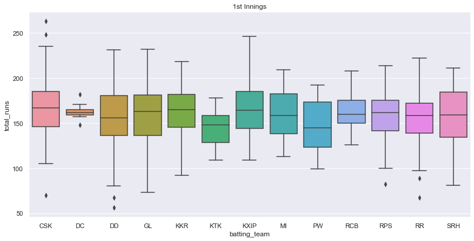

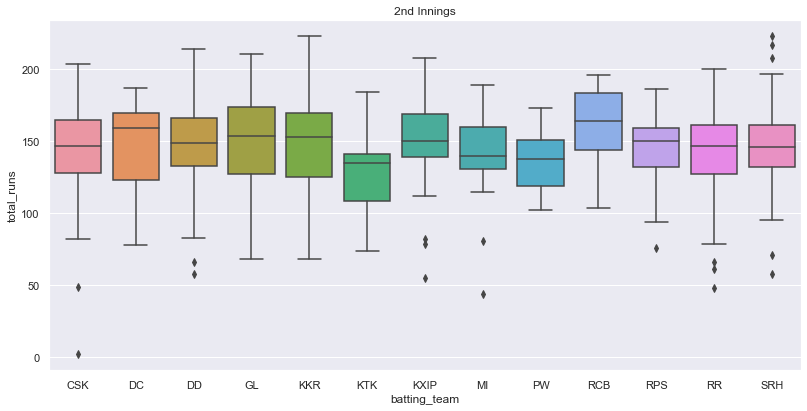

## 200+ Scores

|  | match_id | inning | batting_team | bowling_team | total_runs |
| --- | --- | --- | --- | --- | --- |
| 829 | 411 | 1 | CSK | PW | 263 |
| 1250 | 620 | 1 | CSK | RCB | 248 |
| 416 | 206 | 1 | KXIP | SRH | 246 |
| 122 | 61 | 1 | KXIP | GL | 240 |
| 1134 | 562 | 1 | CSK | KKR | 235 |
| 596 | 296 | 1 | GL | CSK | 232 |
| 522 | 259 | 1 | DD | GL | 231 |
| 981 | 486 | 1 | GL | KXIP | 231 |
| 100 | 50 | 1 | GL | KKR | 230 |
| 1170 | 580 | 1 | CSK | MI | 227 |

```
<function matplotlib.pyplot.show(close=None, block=None)>
```

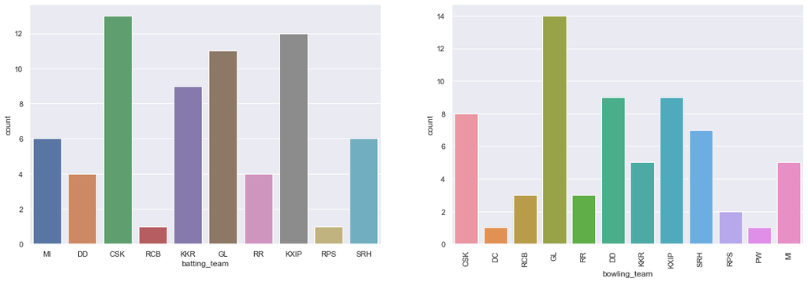

The graph on the left shows the number of times a team has scored above 200 runs. The graph on the right shows the number of times a bowling team has conceeded above 200 runs.

```
Teams who have"nt ever scored 200 runs ['PW', 'KTK', 'DC']
Teams who haven"t conceeded over 200 while bowling ['KTK']
```

| inning | batting_team | bowling_team | count |
| --- | --- | --- | --- |
| 1 | CSK | DD | 1 |
|  |  | GL | 3 |
|  |  | KKR | 1 |
|  |  | KXIP | 1 |
|  |  | MI | 1 |
|  |  | PW | 1 |
|  |  | RCB | 2 |
|  |  | SRH | 1 |
|  | DD | DC | 1 |
|  |  | GL | 1 |
|  |  | KKR | 1 |
|  | GL | CSK | 2 |
|  |  | KKR | 1 |
|  |  | KXIP | 2 |
|  |  | SRH | 1 |
|  | KKR | CSK | 1 |
|  |  | DD | 4 |
|  |  | KXIP | 1 |
|  |  | SRH | 1 |
|  | KXIP | CSK | 1 |
|  |  | DD | 1 |
|  |  | GL | 2 |
|  |  | KKR | 1 |
|  |  | MI | 2 |
|  |  | RR | 1 |
|  |  | SRH | 1 |
|  | MI | CSK | 2 |
|  |  | GL | 2 |
|  |  | RR | 1 |
|  |  | SRH | 1 |
|  | RCB | DD | 1 |
|  | RPS | SRH | 1 |
|  | RR | CSK | 1 |
|  |  | GL | 1 |
|  |  | RPS | 1 |
|  | SRH | DD | 1 |
|  |  | GL | 1 |
|  |  | KXIP | 1 |
| 2 | CSK | GL | 1 |
|  |  | MI | 1 |
|  | DD | RCB | 1 |
|  | GL | DD | 1 |
|  |  | KXIP | 2 |
|  |  | MI | 1 |
|  |  | RR | 1 |
|  | KKR | GL | 1 |
|  |  | KXIP | 1 |
|  | KXIP | CSK | 1 |
|  |  | GL | 1 |
|  |  | SRH | 1 |
|  | RR | GL | 1 |
|  | SRH | KKR | 1 |
|  |  | KXIP | 1 |
|  |  | RPS | 1 |

|  | match_id | inning_1 | batting_team | bowling_team | inning1_runs | inning_2 | inning2_runs | is_score_chased |
| --- | --- | --- | --- | --- | --- | --- | --- | --- |
| 0 | 1 | 1 | MI | CSK | 207 | 2 | 172 | no |
| 8 | 9 | 1 | DD | DC | 205 | 2 | 108 | no |
| 19 | 20 | 1 | CSK | RCB | 213 | 2 | 192 | no |
| 31 | 32 | 1 | MI | GL | 207 | 2 | 181 | no |
| 35 | 36 | 1 | MI | RR | 209 | 2 | 161 | no |

### Chances of chasing 200+ target

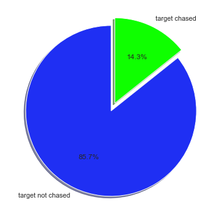

|  | batsman | balls | runs | strike_rate | 6's | 4's | Team | Highest_score |
| --- | --- | --- | --- | --- | --- | --- | --- | --- |
| 0 | A Ashish Reddy | 196 | 280 | 142.857143 | 16 | 15 | MI | 36 |
| 1 | A Ashish Reddy | 196 | 280 | 142.857143 | 16 | 15 | RPS | 10 |
| 2 | A Chandila | 7 | 4 | 57.142857 | 0 | 0 | SRH | 4 |
| 3 | A Chopra | 75 | 53 | 70.666667 | 7 | 0 | RR | 24 |
| 4 | A Choudhary | 20 | 25 | 125.000000 | 1 | 1 | CSK | 15 |

[output not shown]

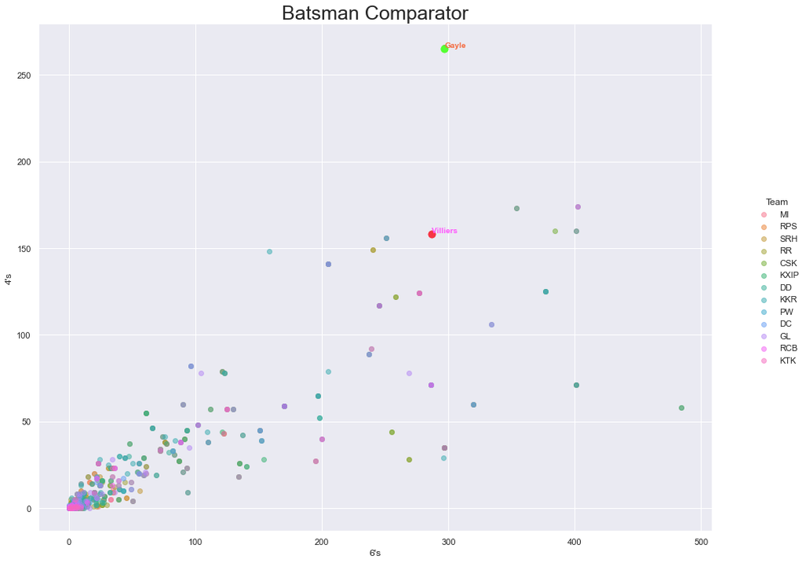

**Dhoni Vs Kohli**

[output not shown]

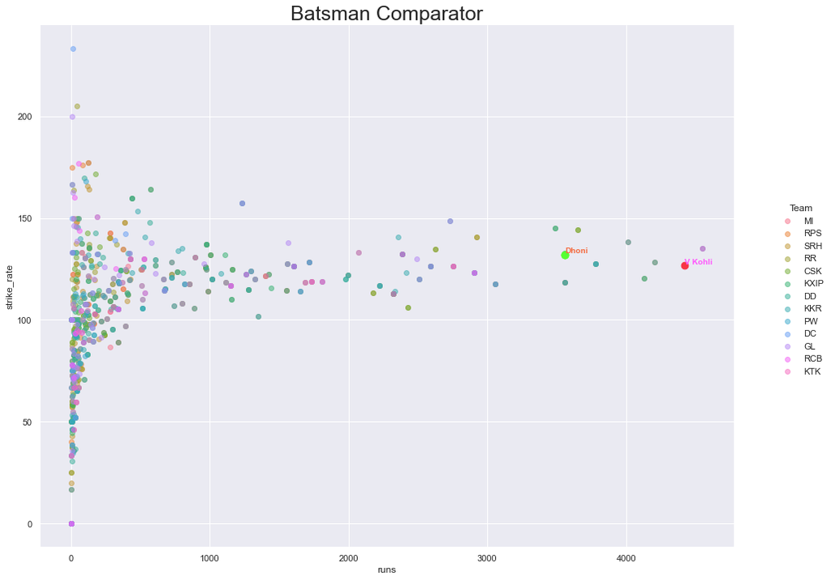

**Top 10 Batsman**

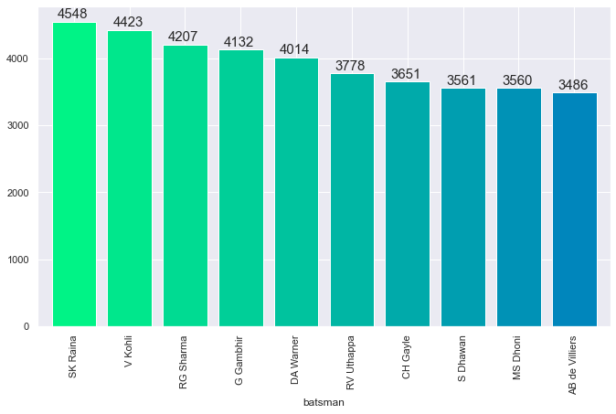

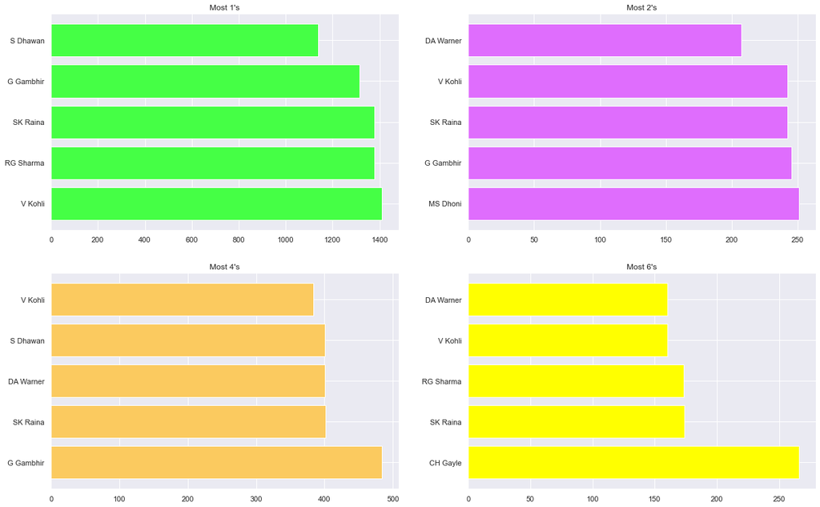

**Top Individual Scores**

|  | match_id | batsman | batting_team | batsman_runs |
| --- | --- | --- | --- | --- |
| 6200 | 411 | CH Gayle | CSK | 175 |
| 900 | 60 | BB McCullum | RR | 158 |
| 8426 | 562 | AB de Villiers | CSK | 133 |
| 9257 | 620 | AB de Villiers | CSK | 129 |
| 5585 | 372 | CH Gayle | CSK | 128 |
| 3135 | 206 | M Vijay | KXIP | 127 |
| 529 | 36 | DA Warner | MI | 126 |
| 7752 | 516 | V Sehwag | GL | 122 |
| 3686 | 243 | PC Valthaty | GL | 120 |
| 4223 | 279 | V Sehwag | DD | 119 |

**Individual Scores By Top Batsman each Inning**

[output not shown]

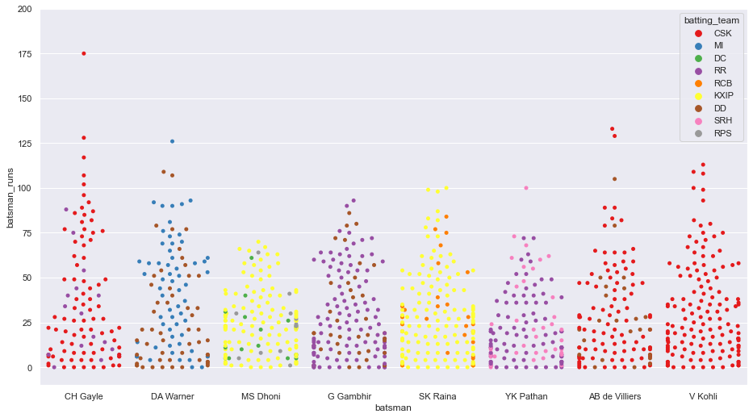

**Runs Scored By Batsman Across Seasons**

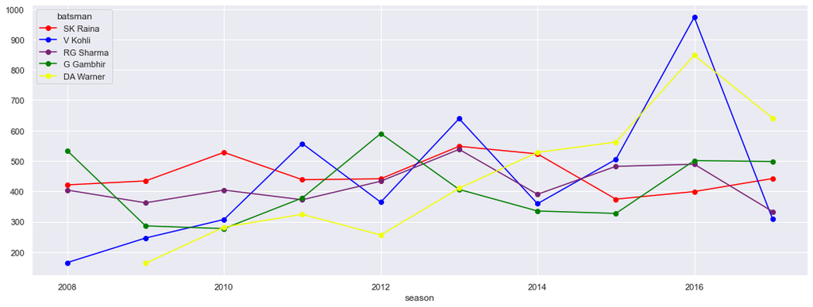

**How do the top batsmen score? (INTERACTIVE)**

[interactive chart not shown]

**Frequency of Scores**

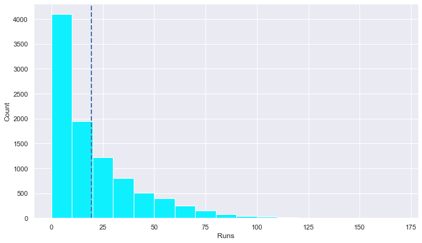

**Orange Caps Each Season(Highest Run Getter per Season) (INTERACTIVE)**

[interactive chart not shown]

## Top Bowlers, Highest Wicket Taker, maximum over, gighest dimissals for batsmean by bowler, purple caps each season, etc

**Highest Wicket Taker**

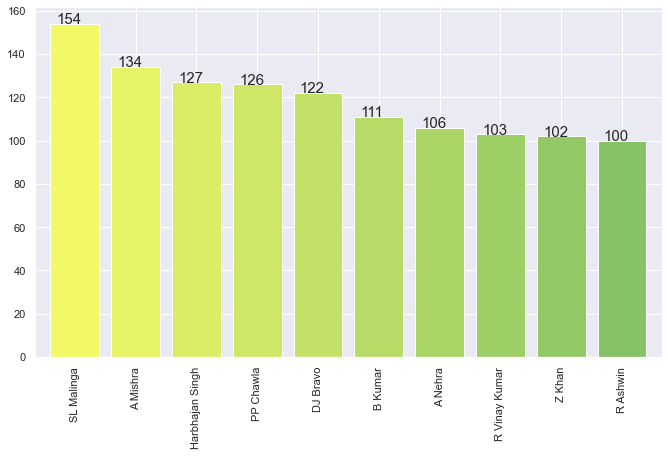

**Maximum Overs**

|  | bowler | overs |
| --- | --- | --- |
| 0 | Harbhajan Singh | 498 |
| 1 | A Mishra | 450 |
| 2 | SL Malinga | 449 |
| 3 | P Kumar | 439 |
| 4 | PP Chawla | 432 |

|  | 0 | 1 | 2 | 3 | 4 | 5 | 6 | 7 | 8 | 9 |
| --- | --- | --- | --- | --- | --- | --- | --- | --- | --- | --- |
| bowler | SP Narine | R Ashwin | DW Steyn | SL Malinga | Harbhajan Singh | B Kumar | A Mishra | PP Ojha | Z Khan | P Kumar |
| economy | 6.395706 | 6.493639 | 6.615599 | 6.757238 | 6.933735 | 7.046784 | 7.344444 | 7.404321 | 7.546174 | 7.612756 |

**Top 20 Bowlers (INTERACTIVE)**

|  | bowler | runs_given | overs | wickets | economy |
| --- | --- | --- | --- | --- | --- |
| 5 | A Mishra | 3305 | 450 | 134.0 | 7.344444 |
| 7 | A Nehra | 2537 | 329 | 106.0 | 7.711246 |
| 50 | B Kumar | 2410 | 342 | 111.0 | 7.046784 |
| 88 | DJ Bravo | 2815 | 351 | 122.0 | 8.019943 |
| 103 | DW Steyn | 2375 | 359 | 92.0 | 6.615599 |

[interactive chart not shown]

**Highest Dismissals for a Batsman by a Bowler**

|  | batsman | bowler | No_of_Dismissals |
| --- | --- | --- | --- |
| 0 | CH Gayle | R Ashwin | 4 |
| 0 | V Kohli | A Nehra | 6 |
| 0 | SK Raina | Harbhajan Singh | 5 |
| 0 | AB de Villiers | KH Pandya | 4 |
| 0 | MS Dhoni | Z Khan | 7 |
| 0 | G Gambhir | Z Khan | 6 |
| 0 | RG Sharma | R Vinay Kumar | 6 |
| 0 | RV Uthappa | A Mishra | 4 |
| 0 | S Dhawan | Z Khan | 4 |
| 0 | DA Warner | L Balaji | 3 |

**Frequency Of Economy**

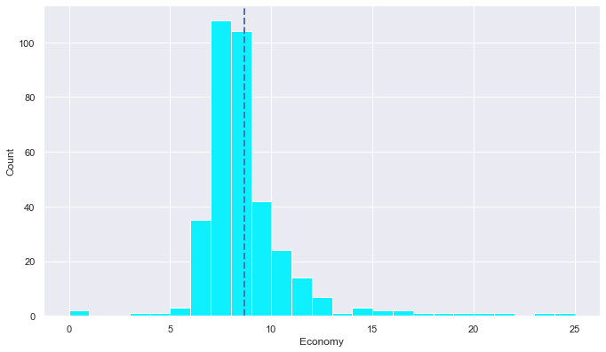

**Purple Caps Each Season (Maximum Wickets By Bowler per Season) (INTERACTIVE)**

[interactive chart not shown]

## Extras And Wickets & Teams with maximum Boundaries

**Extras And Wickets (INTERACTIVE)**

[interactive chart not shown]

**Teams with maximum Boundaries (INTERACTIVE)**

[interactive chart not shown]

## How to win Finals?

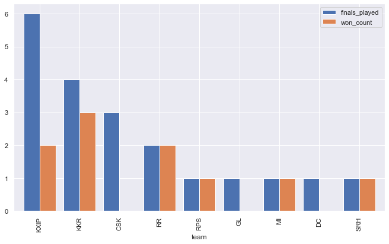

**Do Toss Winners Win Finals??**

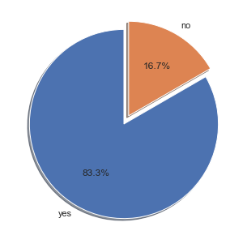

**Batting Or Fielding For Toss Winners**

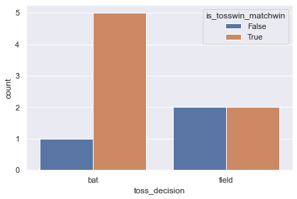

[figure not shown]